# Monte Carlo Methods in R

A self-study module with exercises and solutions

Author

Adapted from Ben Staton, *Introduction to R for Natural Resource Scientists*, Chapter 4

Published

September 28, 2026

# About this module

This module teaches the basic programming skills you need to run **Monte Carlo simulations** in R. It is based on Chapter 4 of Ben Staton’s open textbook [*Introduction to R for Natural Resource Scientists*](https://bstaton1.github.io/au-r-workshop/ch4.html) and its [exercise solutions](https://bstaton1.github.io/au-r-workshop/exercise-solutions.html#ex4-answers). The book is released under CC0. The text and code have been reorganised for self-study, and the changes are listed in Changes from the original material.

## Learning objectives

After working through this module you should be able to:

1. introduce randomness into a model with **random deviates** (`rbinom()`, `rnorm()`, `rlnorm()`, …) and **resampling** (`sample()`);
2. make random results **reproducible** with `set.seed()`;
3. **replicate** a random process many times with `replicate()`, `for()` loops and `sapply()`;
4. wrap a simulation in a **function** with sensible arguments and defaults;
5. **summarise** Monte Carlo output (means, quantiles, frequencies and probabilities);
6. apply these skills to five standard analyses:
   - checking a random number generator
   - a stochastic **power analysis**
   - a **harvest policy** simulation
   - a **bootstrap**
   - a **permutation test**

## How to use this module

- **Time:** about 4–6 hours. Part I (Sections 1–5) takes about 1.5 hours. Each example in Part II takes 30–45 minutes.
- **Prerequisites:** basic R (vectors, data frames, `apply()`, plotting), linear models, `glm()` for logistic regression, and `nls()`.
- **Working style:** create a new R script (e.g. `MC_self_study.R`) and *type* the code yourself rather than copy-pasting it. Run each line and look at what it produces.
- **Exercises** are at the end of each section in Part II and in Part III. The solutions are in collapsed boxes. **Make a serious attempt first.**
- Your numbers will differ slightly from those shown here, because the results are random. That is the point of the module.

## Setup: the `qsbsdata` data package

All data sets used in this module are in the course data package **`qsbsdata`** (version 0.2.0 or later). Install it once:

```r
# install.packages("remotes")   # only needed once
remotes::install_github("emielvanloon/qsbsdata")
```

Then load it at the start of every session:

```r
library(qsbsdata)
```

The data sets are available as data frames, e.g. `growth`, `ponds` and `sockeye_redfish`. Run `?qsbsdata` for an overview. Note that the book’s `sockeye` data set is called **`sockeye_redfish`** in `qsbsdata`, because `qsbsdata` already contains a different `sockeye` data set (Fraser River salmon). The original CSV files are included as well:

```r
list.files(system.file("extdata", package = "qsbsdata"))
read.csv(system.file("extdata", "growth.csv", package = "qsbsdata"))
```

**NoteWhat is a Monte Carlo method?**

Monte Carlo methods **draw random samples many times** in order to build and summarise the distribution of some quantity of interest. R is well suited to this. You can repeat the same calculation (possibly a long and complicated one) thousands of times, each time with different random values, and then summarise and plot all the results in the same program.

# Part I – Required material

# 1 Introducing randomness

A **random process** gives a different outcome each time it runs, according to a set of rules. Random processes are closely tied to **uncertainty**, because you do not know the outcome of the next run in advance. R has two basic ways of introducing randomness: **random deviates** and **resampling**.

## 1.1 Random deviates

The `r-` family of distribution functions (`rnorm()`, `rbinom()`, `rpois()`, …) generates random numbers from a probability distribution.

Consider animal survival. Each individual that is alive at the start of the year either lives or dies by the end of it. Suppose each animal survives with probability 0.8. The number of survivors out of $n$ animals is then the outcome of a **binomial random process** with $n$ trials and success probability $p$. One realisation with $p = 0.8$ and $n = 100$:

```r
rbinom(n = 1, size = 100, prob = 0.8)
```

```
[1] 83
```

Your result will almost certainly differ from the one printed here. That is the random component.

The `n` argument sets how many such processes to run. Plot the distribution of the number of survivors:

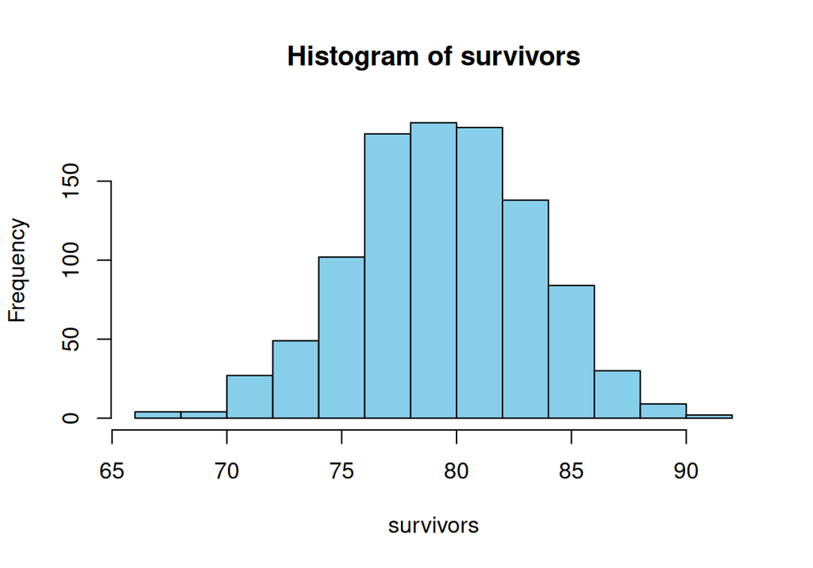

```r
survivors <- rbinom(1000, 100, 0.8)
hist(survivors, col = "skyblue")
```

Another example is the **lognormal process**. It generates numbers whose logarithm is normally distributed with mean `meanlog` and standard deviation `sdlog`:

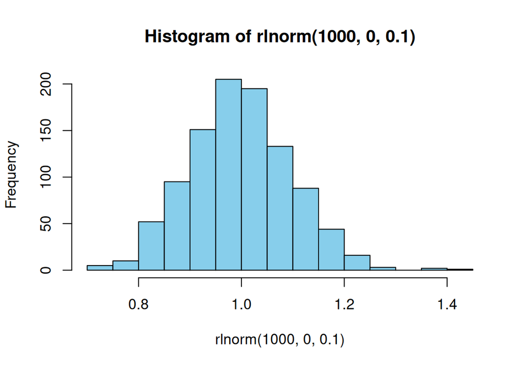

```r
hist(rlnorm(1000, 0, 0.1), col = "skyblue")
```

**TipCommon `r`-functions**

`rnorm()`, `rlnorm()`, `rbinom()`, `rpois()`, `rnbinom()`, `runif()`, `rbeta()`, `rgamma()`, `rexp()`, `rmultinom()`. Each has matching `d-` (density), `p-` (cumulative probability) and `q-` (quantile) functions.

## 1.2 Resampling

Random deviates create *new* random numbers. Sometimes, though, you want to add randomness to a set of numbers you already have. **Resampling** does this. `sample()` draws `size` elements from the vector `x`:

```r
sample(x = 1:10, size = 5)
```

```
[1]  9  3  5  7 10
```

Sample *with replacement*, so the same element can be drawn more than once:

```r
sample(x = c("a", "b", "c"), size = 10, replace = T)
```

```
 [1] "b" "c" "a" "b" "c" "b" "a" "b" "a" "c"
```

Give the elements different sampling probabilities. If `prob` does not sum to 1, R rescales it.

```r
sample(x = c("live", "die"), size = 10, replace = T,
       prob = c(0.8, 0.2))
```

```
 [1] "live" "live" "live" "die"  "live" "live" "live" "live" "live" "die"
```

This is the same as the binomial process above, but with only 10 trials, and it returns the individual outcomes instead of the number of successes.

# 2 Reproducing randomness

For reproducibility you may want the same random numbers every time you run your script. You do this by setting the **random seed**, the starting point of the random number generator. These two lines should give exactly the result printed here:

```r
set.seed(1234)
rnorm(1)
```

```
[1] -1.207066
```

**Important**

Set the seed **once**, at the top of a script. Do not set it inside a loop: that would give the same “random” numbers in every iteration.

# 3 Replication

Monte Carlo methods need a random process to be repeated many times. The two most common ways of doing this are `replicate()` and `for()` loops.

## 3.1 `replicate()`

`replicate()` evaluates an expression many times and returns the output of every evaluation. Say `x` holds 30 fish lengths (mm):

```r
x <- rnorm(30, 500, 30)
```

Build the sampling distribution of the mean “by hand”: resample `x` with replacement, compute the mean, and repeat many times.

```r
means <- replicate(n = 1000, expr = {
  x_i <- sample(x, length(x), replace = T)
  mean(x_i)
})
```

`mean(means)` and `sd(means)` should be close to `mean(x)` and the standard error of `x`. Check this:

```r
se <- function(x) sd(x)/sqrt(length(x))
mean(means); mean(x)
```

```
[1] 493.4968
```

```
[1] 493.4166
```

```r
sd(means); se(x)
```

```
[1] 4.967572
```

```
[1] 5.044153
```

## 3.2 The `for()` loop

A `for()` loop repeats an action **for** each value in a vector:

```r
for (var in seq) {
  expression(var)
}
```

For example:

```r
for (i in 1:5) {
  print(i^2)
}
```

```
[1] 1
[1] 4
[1] 9
[1] 16
[1] 25
```

Without `print()`, R does the calculation but neither shows nor stores the result. Usually you store the results in a **container object**:

```r
results <- numeric(5)
for (i in 1:5) {
  results[i] <- i^2
}
results
```

```
[1]  1  4  9 16 25
```

You would never use a loop for something this simple: `(1:5)^2` gives the same result. Loops are useful when:

1. a calculation depends on the result of the previous iteration (for example, time-series models);
2. each iteration involves several steps;
3. you want to store several results per iteration;
4. you want to track progress.

Point 1 is illustrated by a (very) basic population model:

- The population starts at 1000 individuals and grows by an average factor of 1.1 per year before harvest.
- The growth factor varies randomly from year to year. We model this variation with a lognormal random variable.
- After growth, 8 % of the population is harvested.

Simulate 100 years:

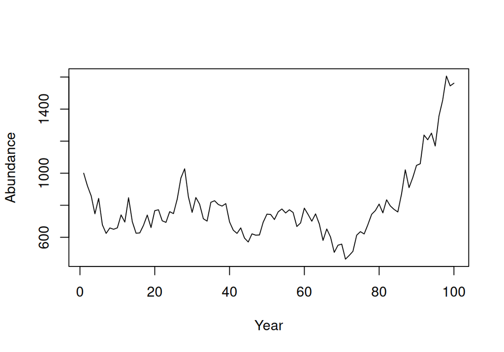

```r
nt <- 100       # number of years
N <- NULL       # container for abundance
N[1] <- 1000    # first end-of-year abundance

for (t in 2:nt) {
  # N this year = N last year * growth * randomness * fraction surviving harvest
  N[t] <- (N[t-1] * 1.1 * rlnorm(1, 0, 0.1)) * (1 - 0.08)
}

plot(N, type = "l", xlab = "Year", ylab = "Abundance")
```

# 4 Function writing

In Monte Carlo work it is often useful to wrap a simulation in a function. The function can then be replicated easily and run with different settings. Here is the population model written as a function:

```r
pop_sim <- function(nt, grow, sd_grow, U, plot = F) {
  N <- NULL # empty flexible vector container
  N[1] <- 1000
  for (t in 2:nt) {
    N[t] <- (N[t-1] * grow * rlnorm(1, 0, sd_grow)) * (1 - U)
  }

  if (plot) {
    plot(N, type = "l", xlab = "Year", ylab = "Abundance")
  }

  N
}
```

Arguments:

- `nt`: number of years
- `grow`: population growth rate
- `sd_grow`: annual variability in the growth rate
- `U`: annual exploitation rate
- `plot`: whether to draw a plot (default `FALSE`)

The function returns the vector of abundances. Run it once:

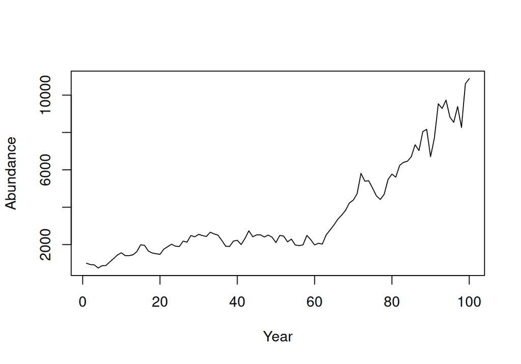

```r
N_one <- pop_sim(100, 1.1, 0.1, 0.08, T)
```

Replicate it 1000 times:

```r
out <- replicate(n = 1000, expr = pop_sim(100, 1.1, 0.1, 0.08, F))
dim(out)
```

```
[1]  100 1000
```

Years are rows (100) and replicates are columns (1000).

**NoteWhy write functions?**

- You don’t have to retype the same code in several places.
- A change to the behaviour only has to be made in one place.
- Settings (e.g. plotting on or off) are easy to change.
- Scripts become shorter and, with good names, easier to read.

# 5 Summarisation

After replicating a calculation many times, you need to summarise the results. The examples below use the `out` matrix from Section 4.

## 5.1 Central tendency

Mean abundance per year across the iterations:

```r
N_mean <- apply(out, 1, mean)
N_mean[1:10]
```

```
 [1] 1000.000 1017.150 1034.970 1052.022 1068.358 1086.700 1102.685 1125.383
 [9] 1141.774 1159.921
```

`median` works in the same way.

## 5.2 Variability

A main reason for running a Monte Carlo analysis is to estimate **variability**. `quantile()` is the key function:

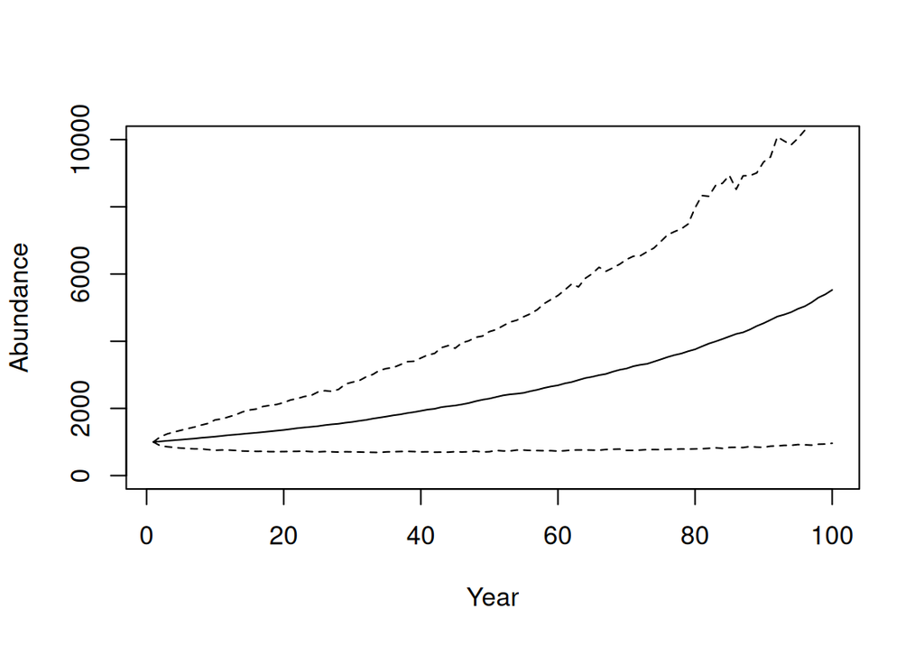

```r
# 10% and 90% quantiles each year across iterations
N_quants <- apply(out, 1, function(x) quantile(x, c(0.1, 0.9)))

plot(N_mean, type = "l", ylim = c(0, 10000),
     xlab = "Year", ylab = "Abundance")
lines(N_quants[1,], lty = 2)
lines(N_quants[2,], lty = 2)
```

The dashed lines enclose the central 80 % of the simulated abundances in each year.

## 5.3 Frequencies

Often you want to know how often something happened. The fraction of iterations in which an event occurred can be read as its **probability**.

How many iterations had fewer than 1000 individuals in year 10, and fewer than 1100 in year 20?

```r
out10 <- ifelse(out[10,] < 1000, "less10", "greater10")
out20 <- ifelse(out[20,] < 1100, "less20", "greater20")
table(out10)
```

```
out10
greater10    less10
      649       351
```

```r
table(out20)
```

```
out20
greater20    less20
      587       413
```

```r
table(out10, out20)
```

```
           out20
out10       greater20 less20
  greater10       486    163
  less10          101    250
```

Divide by the number of iterations to get (joint) probabilities. These are only as good as your model’s representation of reality.

```r
round(table(out10, out20)/1000, 2)
```

```
           out20
out10       greater20 less20
  greater10      0.49   0.16
  less10         0.10   0.25
```

**TipTrick: the mean of a logical vector**

`mean(out[10,] < 1000)` gives the proportion of `TRUE`s directly, so you don’t need `ifelse()` + `table()`.

# Part II – Worked examples

Each example applies the skills from Part I, and each one introduces a few new tricks, so work through all of them if you can. The exercises for each example are in Part III.

# 6 Example: test `rnorm()`

Check that random deviates from `rnorm()` behave as the theoretical normal distribution given by `qnorm()` and `pnorm()` says they should.

```r
mu <- 500; sig <- 30
random <- rnorm(100, mu, sig)
```

**Quantiles.** Compare the empirical quantiles of the sample with the theoretical quantiles from `qnorm()`:

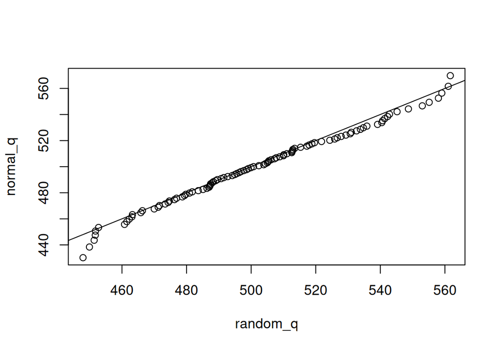

```r
p <- seq(0.01, 0.99, 0.01)
random_q <- quantile(random, p)
normal_q <- qnorm(p, mu, sig)
plot(normal_q ~ random_q); abline(c(0,1))
```

The points fall close to the 1:1 line, so the sample is consistent with a normal distribution. The deviations are sampling error, and they disappear if you increase `n` to `1e6`. This is a **Q–Q plot**.

**Cumulative distribution.** Compare the empirical CDF (`ecdf()`) with `pnorm()`:

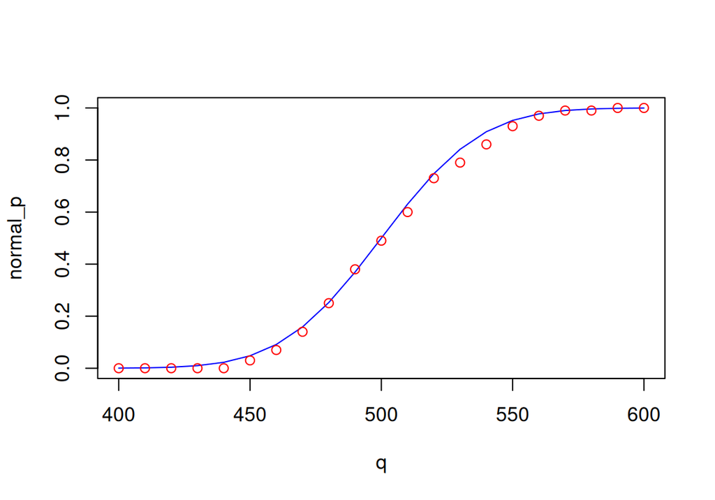

```r
q <- seq(400, 600, 10)
random_cdf <- ecdf(random)
random_p <- random_cdf(q)
normal_p <- pnorm(q, mu, sig)
plot(normal_p ~ q, type = "l", col = "blue")
points(random_p ~ q, col = "red")
```

`ecdf()` returns a *function*. Give it any value, and it returns the proportion of the sample that lies at or below that value.

# 7 Example: stochastic power analysis

**Power** is the probability of detecting an effect when the effect really exists, i.e. 1 − P(Type II error). It depends on the effect size, the sample size and the variability of the data. A Monte Carlo simulation can estimate it.

**The problem.**

- A standard fish-tagging method kills about 10 % of the tagged fish within 12 hours.
- A cheaper method has been proposed. If its mortality reaches 25 %, the savings are cancelled out, because more fish have to be tagged.
- A pilot study will tag `n` fish with each method, **at most 100 fish in total**.

Could fewer than 100 fish give a high probability of detecting the difference?

**Pseudocode**

1. Simulate data in which the difference is real, with `n` observations per treatment.
2. Fit the model you will use on the real data (a logistic regression).
3. Record whether the p-value is significant.
4. Repeat steps 1–3 many times.
5. Repeat step 4 for `n` from 10 to 50.
6. At each `n`, compute the fraction of significant results.

A function for steps 1–3:

```r
sim_fit <- function(n, p_old = 0.10, p_new = 0.25) {

  ### step 1: create the data ###
  dead_old <- rbinom(n, size = 1, prob = p_old)
  dead_new <- rbinom(n, size = 1, prob = p_new)
  # predictor variable, with "old" as the reference level
  method <- factor(rep(c("old", "new"), each = n), levels = c("old", "new"))
  df <- data.frame(dead = c(dead_old, dead_new), method = method)

  ### step 2: fit the model ###
  fit <- glm(dead ~ method, data = df, family = binomial)

  ### step 3: determine if a sig. p-value was found ###
  pval <- summary(fit)$coef[2,4]
  pval < 0.05
}
```

Steps 4 and 5 use a **nested `for()` loop**: the outer loop runs over sample sizes and the inner loop over replicates.

```r
I <- 500                  # replicates per sample size
n_try <- seq(10, 50, 10)  # sample sizes to try
N <- length(n_try)
out <- matrix(NA, I, N)   # container: I rows, N columns

for (n in 1:N) {
  for (i in 1:I) {
    out[i,n] <- sim_fit(n = n_try[n])
  }
}
```

The column means of this `TRUE`/`FALSE` matrix are the power estimates:

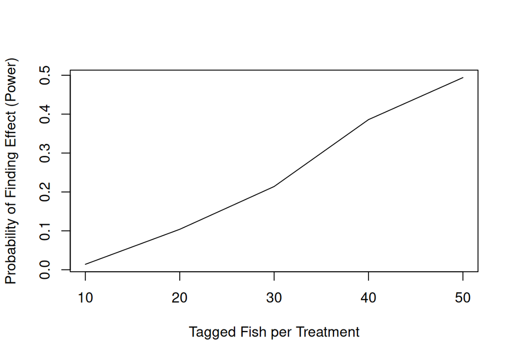

```r
plot(apply(out, 2, mean) ~ n_try, type = "l",
     xlab = "Tagged Fish per Treatment",
     ylab = "Probability of Finding Effect (Power)")
```

Even with 100 fish in total (50 per treatment), the chance of detecting the real effect is only about 50 %.

**Precision instead of significance.** Suppose you care about the effect *size* rather than the p-value. How often is the estimated mortality of the new method within ±0.05 of the true value (i.e. between 0.20 and 0.30)?

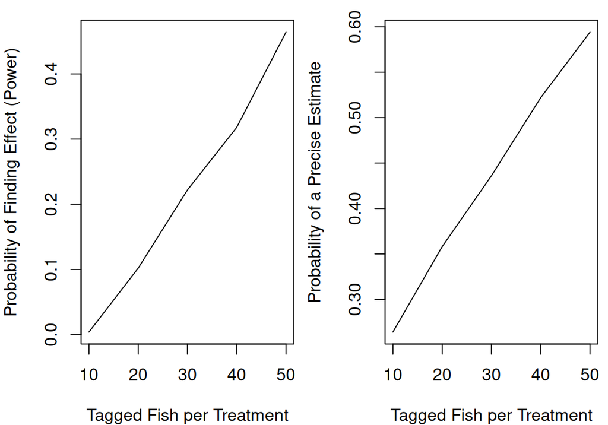

```r
sim_fit <- function(n, p_old = 0.10, p_new = 0.25) {
  dead_old <- rbinom(n, size = 1, prob = p_old)
  dead_new <- rbinom(n, size = 1, prob = p_new)
  method <- factor(rep(c("old", "new"), each = n), levels = c("old", "new"))
  df <- data.frame(dead = c(dead_old, dead_new), method = method)
  fit <- glm(dead ~ method, data = df, family = binomial)
  # significance
  pval <- summary(fit)$coef[2,4]
  sig_pval <- pval < 0.05
  # estimated mortality rate of the new method
  p_new_est <- predict(fit, data.frame(method = "new"), type = "response")
  # within +/- 0.05 of the true value?
  prc_est <- p_new_est >= (p_new - 0.05) & p_new_est <= (p_new + 0.05)
  c(sig_pval = sig_pval, prc_est = unname(prc_est))
}

out_sig <- matrix(NA, I, N)
out_prc <- matrix(NA, I, N)
for (n in 1:N) {
  for (i in 1:I) {
    tmp <- sim_fit(n = n_try[n])
    out_sig[i,n] <- tmp["sig_pval"]
    out_prc[i,n] <- tmp["prc_est"]
  }
}

par(mfrow = c(1,2), mar = c(4,4,1,0.5))
plot(apply(out_sig, 2, mean) ~ n_try, type = "l",
     xlab = "Tagged Fish per Treatment",
     ylab = "Probability of Finding Effect (Power)")
plot(apply(out_prc, 2, mean) ~ n_try, type = "l",
     xlab = "Tagged Fish per Treatment",
     ylab = "Probability of a Precise Estimate")
```

Even with 50 fish per treatment, the chance of a precise estimate is only about 60 %. The conclusion: find money to tag more fish.

# 8 Example: harvest policy analysis

Here you simulate a more realistic population model in order to compare **harvest policies**.

**The problem.**

- A commercial fishery for pink salmon (*Oncorhynchus gorbuscha*) has been run for 10 years at an exploitation rate of $U = 0.4$.
- Over that period the average annual harvest was 8.5 million fish.
- Could a different $U$ sustain a larger harvest?

The stock follows **Ricker spawner–recruit** dynamics:

$$R_t = \alpha S_{t-1} e^{-\beta S_{t-1} + \varepsilon_t}, \qquad \varepsilon_t \sim N(0,\sigma)$$

- $\alpha$ is the maximum number of recruits per spawner.
- $\beta$ is the strength of density dependence.
- $e^{\varepsilon_t}$ is lognormal process noise.

The parameter estimates are $\alpha = 6$, $\beta = 10^{-7}$ and $\sigma = 0.4$. In reality these estimates would themselves be uncertain; that uncertainty is ignored here.

The function has three jobs:

1. take the parameters, the number of years and the policy $U$ as input;
2. simulate the Ricker dynamics;
3. return the mean harvest and the mean escapement.

```r
ricker_sim <- function(ny, params, U) {
  # extract the parameters by name
  alpha <- params["alpha"]
  beta <- params["beta"]
  sigma <- params["sigma"]
  # containers (a neat trick to condense your code)
  R <- S <- H <- NULL
  # initialise at the equilibrium under U = 0.4, with lognormal error
  R[1] <- log(alpha * (1 - 0.4))/(beta * (1 - 0.4)) * exp(rnorm(1, 0, sigma))
  S[1] <- R[1] * (1 - U)
  H[1] <- R[1] * U

  # carry the simulation forward through time
  for (y in 2:ny) {
    R[y] <- S[y-1] * alpha * exp(-beta * S[y-1] + rnorm(1, 0, sigma))
    S[y] <- R[y] * (1 - U)
    H[y] <- R[y] * U
  }
  # wrap output in a list
  list(mean_H = mean(H), mean_S = mean(S))
}

params <- c(alpha = 6, beta = 1e-7, sigma = 0.4)
out <- ricker_sim(U = 0.4, ny = 20, params = params)
round(out$mean_H/1e6, digits = 2)   # average annual harvest (millions)
```

```
[1] 7.99
```

The **Monte Carlo** part is to apply each fixed policy many times to a random system. The **policy** part is to compare candidate values of $U$. This time use `sapply()` (over $U$) around `replicate()` (over random populations) instead of a nested loop:

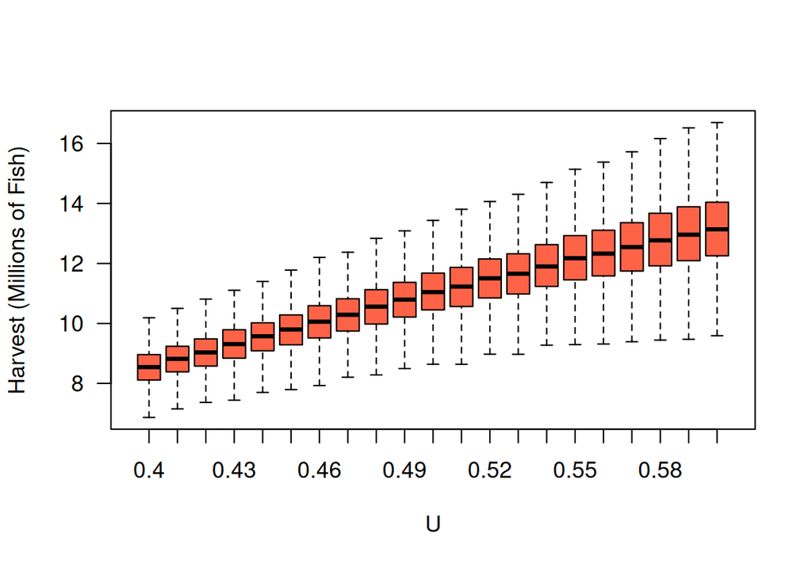

```r
U_try <- seq(0.4, 0.6, 0.01)
n_rep <- 2000
H_out <- sapply(U_try, function(u) {
  replicate(n = n_rep, expr = {
    ricker_sim(U = u, ny = 20, params = params)$mean_H/1e6
  })
})
colnames(H_out) <- U_try
boxplot(H_out, outline = F,
        xlab = "U", ylab = "Harvest (Millions of Fish)",
        col = "tomato", las = 1)
```

A higher $U$ produces more harvest. However, managers do not want escapement to fall below 75 % of its recent level of about 13 million fish. Compute the average escapement in the same way:

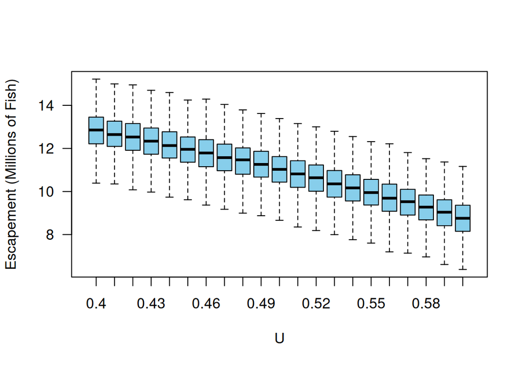

```r
S_out <- sapply(U_try, function(u) {
  replicate(n = n_rep, expr = {
    ricker_sim(U = u, ny = 20, params = params)$mean_S/1e6
  })
})
colnames(S_out) <- U_try
boxplot(S_out, outline = F,
        xlab = "U", ylab = "Escapement (Millions of Fish)",
        col = "skyblue", las = 1)
```

This is a **trade-off**. For each $U$, what is the probability that

- average escapement stays above $0.75 \times 13$ million, and
- average harvest is at least 20 % above the current 8.5 million?

```r
Smeet <- S_out > (0.75 * 13)   # escapement criterion met?
Hmeet <- H_out > (1.2 * 8.5)   # harvest criterion met?
# mean of a logical vector = proportion of TRUEs
p_Smeet <- apply(Smeet, 2, mean)
p_Hmeet <- apply(Hmeet, 2, mean)
```

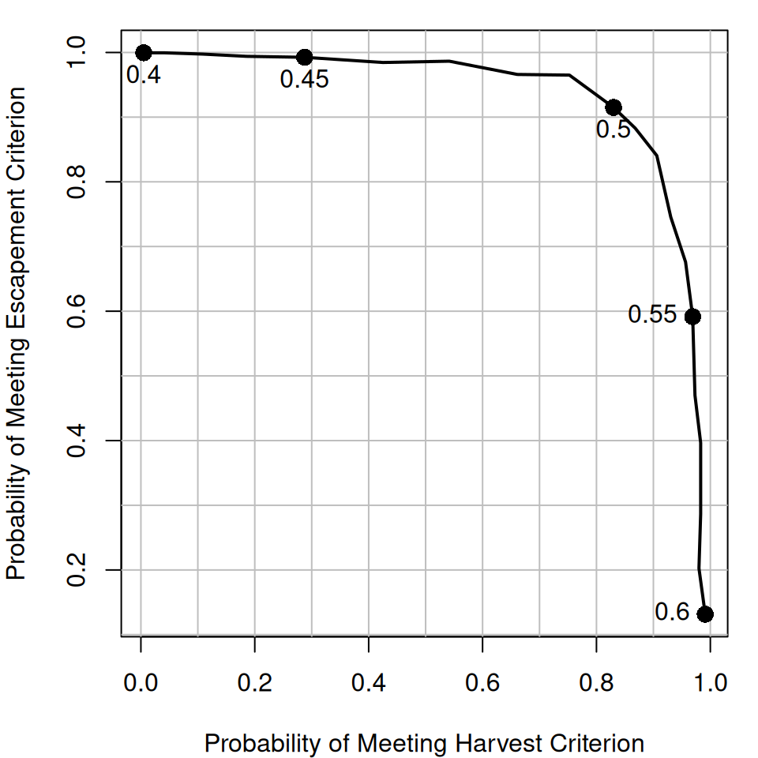

```r
plot_U <- seq(0.4, 0.6, 0.05)
par(mar = c(4,4,1,1))
plot(p_Smeet ~ p_Hmeet, type = "n",
     xlab = "Probability of Meeting Harvest Criterion",
     ylab = "Probability of Meeting Escapement Criterion")
abline(v = seq(0, 1, 0.1), col = "grey")
abline(h = seq(0, 1, 0.1), col = "grey")
lines(p_Smeet ~ p_Hmeet, lwd = 2)
sel <- round(U_try, 2) %in% plot_U
points(p_Smeet[sel] ~ p_Hmeet[sel], pch = 16, cex = 1.5)
text(p_Smeet[sel] ~ p_Hmeet[sel], labels = U_try[sel], pos = c(1,1,1,2,2))
```

- **Status quo ($U = 0.4$):** escapement is almost certain to stay high, but there is essentially no chance of a 20 % gain in harvest.
- **Small increases** (to about 0.45–0.5) buy a large gain on the harvest criterion at little cost to escapement.
- **$U = 0.5$** is a sensible compromise: about a 90 % chance of meeting the escapement target and more than an 80 % chance of meeting the harvest target.

Note that there are analytical solutions for the *expected* harvest under the deterministic Ricker model. Simulation adds the *probabilities* of meeting each criterion.

**NoteWhy `round(U_try, 2) %in% plot_U`?**

`seq(0.4, 0.6, 0.01)` produces floating-point numbers such as `0.45000000000000001`. Comparing them directly with `%in%` can fail silently, so round before comparing.

# 9 Example: the bootstrap

The **bootstrap** resamples an observed data set in order to propagate uncertainty into a *derived* quantity. The example uses the **von Bertalanffy growth model**:

$$L_i = L_\infty\left(1 - e^{-k(\text{age}_i - t_0)}\right) + \varepsilon_i, \qquad \varepsilon_i \sim N(0,\sigma)$$

- $L_\infty$: the maximum average length.
- $k$: a growth coefficient.
- $t_0$: the theoretical age at which length is zero.

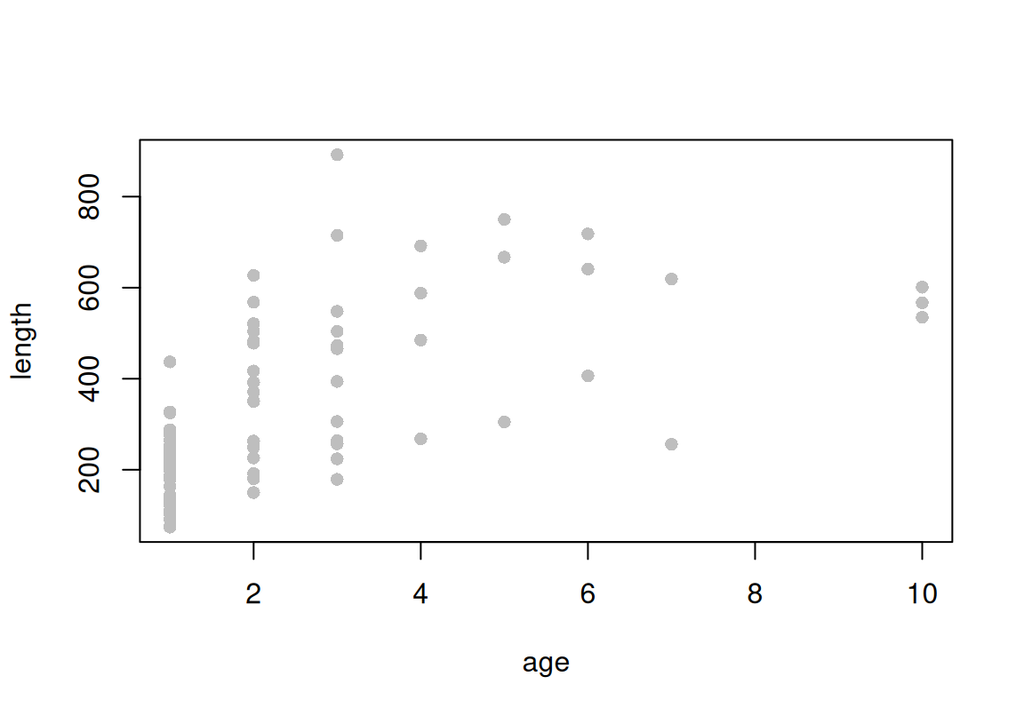

```r
data(growth)
dat <- growth
plot(length ~ age, data = dat, pch = 16, col = "grey")
```

**Question:** what is the probability that an average-sized fish of each age is sexually mature (> 450 mm)?

- Some ages (e.g. 8) have no observations, so the question cannot be answered from the raw data alone.
- Carrying the parameter uncertainty through a non-linear model analytically is awkward.
- The bootstrap solves both problems.

**Pseudocode**

1. Resample the data (rows) with replacement.
2. Fit the model.
3. Derive the quantity of interest (mean length at each age).
4. Repeat steps 1–3 many times.
5. Summarise.

Write one function per step:

```r
randomize <- function(dat) {
  n <- nrow(dat)
  keep <- sample(x = 1:n, size = n, replace = T)  # replace = T is essential!
  dat[keep,]
}

fit_vonB <- function(dat) {
  nls(length ~ linf * (1 - exp(-k * (age - t0))),
      data = dat,
      start = c(linf = 600, k = 0.3, t0 = -0.2))
}

ages <- min(dat$age):max(dat$age)
pred_vonB <- function(fit) {
  ests <- coef(fit)
  ests["linf"] * (1 - exp(-ests["k"] * (ages - ests["t0"])))
}
```

`pred_vonB()` uses `ages`, which is not defined inside the function. R finds it in the enclosing (global) environment. This is called **lexical scoping**; see [*Advanced R*](https://adv-r.hadley.nz/functions.html#lexical-scoping).

One iteration, then many:

```r
pred_vonB(fit = fit_vonB(dat = randomize(dat = dat)))
```

```
 [1] 205.6040 409.6266 462.0091 475.4582 478.9113 479.7978 480.0255 480.0839
 [9] 480.0989 480.1028
```

```r
set.seed(2)
out <- replicate(n = 100, expr = {
  pred_vonB(fit = fit_vonB(dat = randomize(dat = dat)))
})
dim(out)   # rows = ages, columns = bootstrap iterations
```

```
[1]  10 100
```

Summarise and plot:

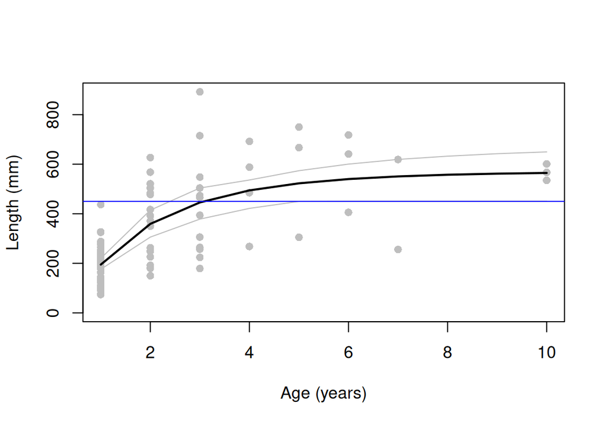

```r
summ <- apply(out, 1, function(x) c(mean = mean(x), quantile(x, c(0.025, 0.975))))

plot(length ~ age, data = dat, col = "grey", pch = 16,
     ylim = c(0, max(dat$length, summ["97.5%",])),
     ylab = "Length (mm)", xlab = "Age (years)")
lines(summ["mean",] ~ ages, lwd = 2)
lines(summ["2.5%",] ~ ages, col = "grey")
lines(summ["97.5%",] ~ ages, col = "grey")
abline(h = 450, col = "blue")
```

The probability that the average fish of each age is mature is the fraction of iterations in which the mean length at that age exceeds 450 mm:

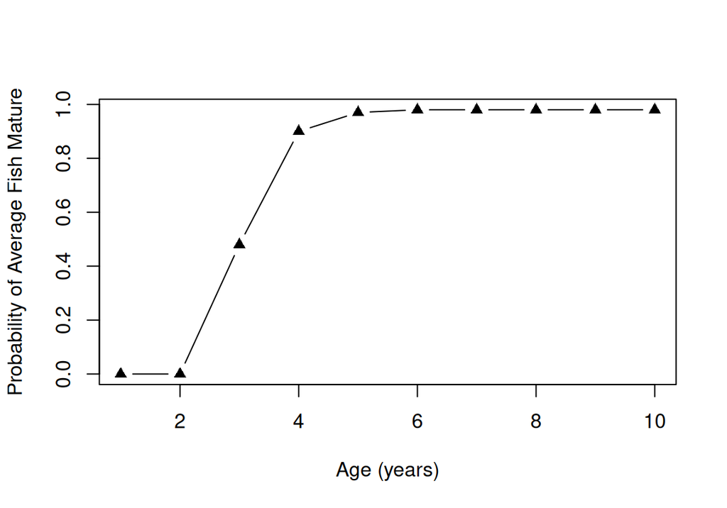

```r
p_mat <- apply(out, 1, function(x) mean(x > 450))
plot(p_mat ~ ages, type = "b", pch = 17,
     xlab = "Age (years)", ylab = "Probability of Average Fish Mature")
```

This **maturity schedule** can help managers decide which ages to protect.

**WarningWhen `nls()` fails**

With non-linear models, a bootstrap sample occasionally fails to converge and `nls()` throws an error. In real analyses, wrap the fit in `tryCatch()`, return `NA` for failed fits, and report how many failed.

# 10 Example: permutation test

A **permutation test** is a non-parametric test for a difference in means between two groups. It is useful when the assumptions of a (generalised) linear model are doubtful.

**Pseudocode**

1. Compute the observed difference in means.
2. Shuffle the group labels at random.
3. Compute the difference between the shuffled groups.
4. Repeat steps 2–3 many times. This gives the **null distribution**, the distribution of the statistic when there is no real difference.
5. The **two-tailed** p-value is the fraction of null values whose absolute value is at least the absolute observed difference.

The data come from a pond experiment in which nutrients were added to half of the mesocosms (`ponds`):

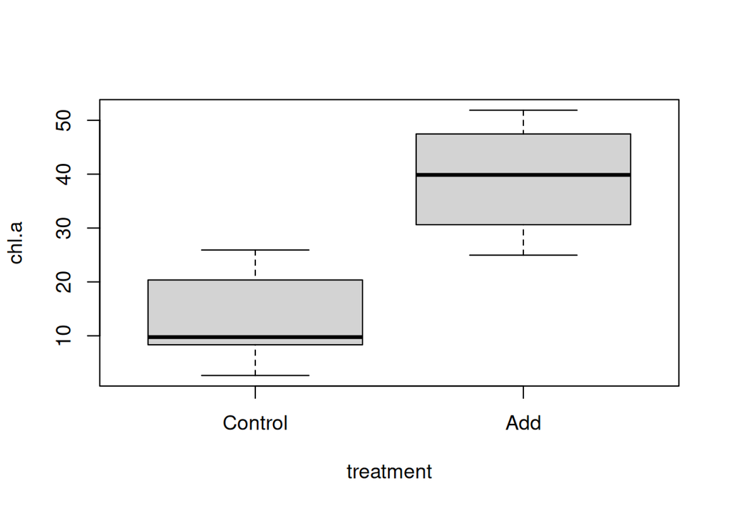

```r
data(ponds)
dat <- ponds
plot(chl.a ~ treatment, data = dat)
```

```r
Dobs <- mean(dat$chl.a[dat$treatment == "Add"]) -
  mean(dat$chl.a[dat$treatment == "Control"])
Dobs
```

```
[1] 26.166
```

A function for one iteration of steps 2–3:

```r
# x is the group (Add or Control), y is chl.a
perm <- function(x, y) {
  x <- as.character(x)
  x_shuff <- sample(x)                 # shuffle the labels
  x_bar_add <- mean(y[x_shuff == "Add"])
  x_bar_ctl <- mean(y[x_shuff == "Control"])
  x_bar_add - x_bar_ctl
}
perm(x = dat$treatment, y = dat$chl.a)
```

```
[1] 10.648
```

Build the null distribution:

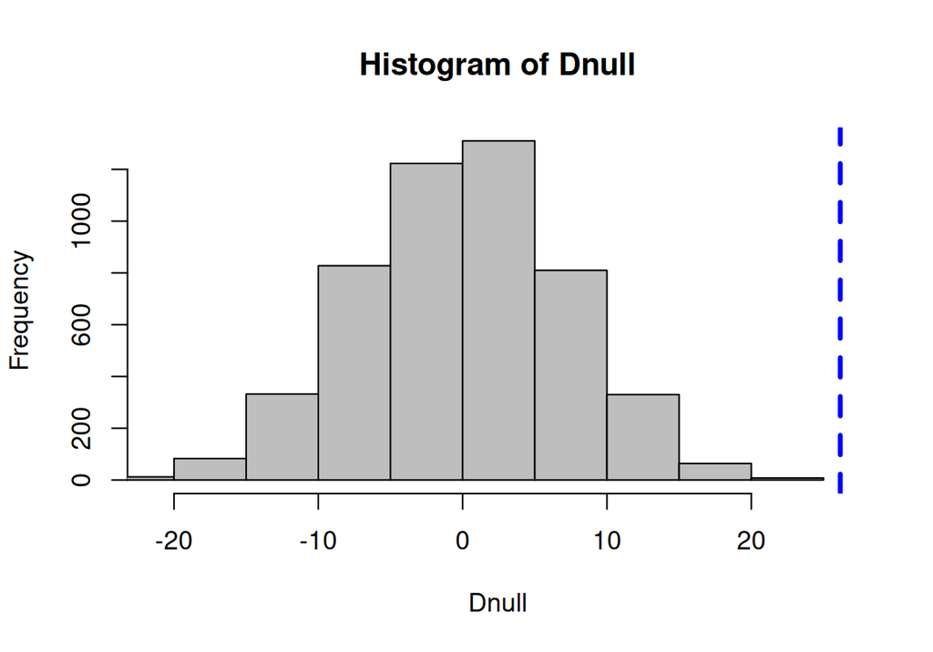

```r
Dnull <- replicate(n = 5000, expr = perm(x = dat$treatment, y = dat$chl.a))
hist(Dnull, col = "grey", xlim = range(c(Dnull, Dobs)))
abline(v = Dobs, col = "blue", lwd = 3, lty = 2)
```

The null distribution is centred on zero, and the observed difference is far out in its upper tail. The two-tailed p-value:

```r
mean(abs(Dnull) >= abs(Dobs))
```

```
[1] 0
```

**NoteTwo refinements**

- Use `abs(Dobs)`, not `Dobs`. Otherwise the test is wrong when the observed difference is negative. The original book code omits the `abs()`.
- A permutation p-value of exactly 0 should really be read as *p < 1/5000*. Many authors therefore use `(sum(abs(Dnull) >= abs(Dobs)) + 1) / (5000 + 1)`, which counts the observed arrangement as one of the permutations.

# Part III – Exercises and solutions

Write a separate script (`Ex_MC.R`) for the exercises so your chapter code stays unchanged. Exercise A uses only Part I. Exercises B–F each build on one worked example.

**Important**

Try each exercise yourself before opening its solution.

# 11 Exercise A: required material only

1. Simulate 100 flips of an unfair coin (P(heads) = 0.6) with `rbinom()`. Count the heads and tails.
2. Simulate the same 100 flips with `sample()`. What fraction are heads?
3. Simulate 100 rolls of a fair six-sided die with `sample()`. What fraction are even?
4. Simulate the same 100 rolls with `rmultinom()` (see `?rmultinom`). What fraction are odd?

**TipSolution A**

**1.**

```r
flips <- rbinom(n = 100, size = 1, prob = 0.6)
flips <- ifelse(flips == 1, "heads", "tails")
table(flips)
```

```
flips
heads tails
   55    45
```

**2.**

```r
flips <- sample(x = c("heads", "tails"), size = 100, replace = T, prob = c(0.6, 0.4))
mean(flips == "heads")
```

```
[1] 0.62
```

**3.**

```r
rolls <- sample(x = 1:6, size = 100, replace = T)
mean(rolls %in% c(2,4,6))
```

```
[1] 0.58
```

**4.** `rmultinom()` returns a matrix: the rows are the six outcomes and the columns are the rolls. Each column contains a single 1.

```r
rolls <- rmultinom(n = 100, size = 1, prob = rep(1, 6))
dim(rolls)
```

```
[1]   6 100
```

```r
sum(rolls[c(1,3,5),])/sum(rolls)
```

```
[1] 0.48
```

# 12 Exercise B: test another distribution

*Builds on Section 6.*

1. Adapt the example to another univariate distribution, e.g. the lognormal, Poisson or beta distribution (`?rpois`, `?rbeta`, …).

**TipSolution B**

This solution uses the **beta distribution**, which takes values between 0 and 1. It is parameterised by a mean `mean_p` and a “precision” `B_sum`; larger `B_sum` means smaller variance.

```r
mean_p <- 0.6
B_sum <- 100
beta_shape <- c(mean_p * B_sum, (1 - mean_p) * B_sum)
random <- rbeta(100, beta_shape[1], beta_shape[2])
```

Test `qbeta()`:

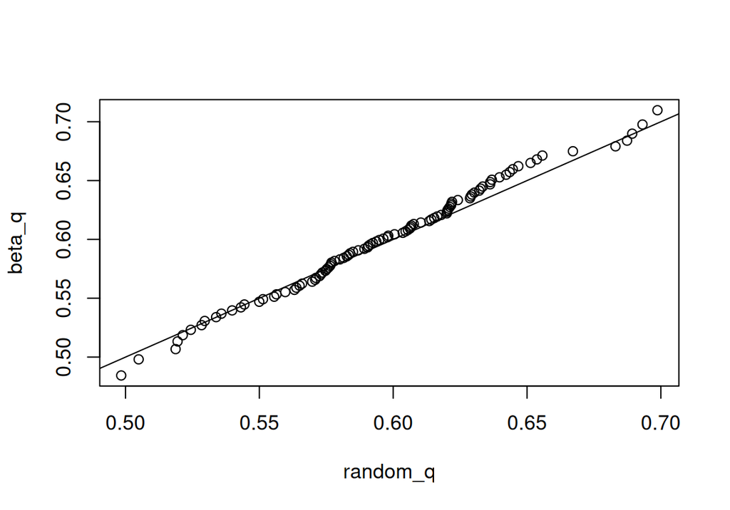

```r
p <- seq(0.01, 0.99, 0.01)
random_q <- quantile(random, p)
beta_q <- qbeta(p, beta_shape[1], beta_shape[2])
plot(beta_q ~ random_q); abline(c(0,1))
```

Test `pbeta()`:

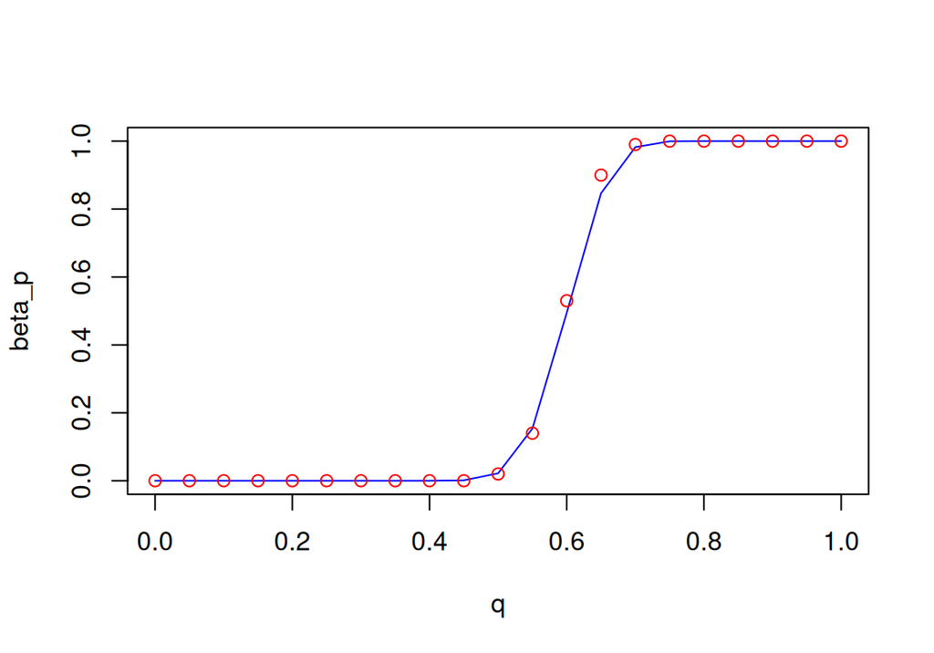

```r
q <- seq(0, 1, 0.05)
random_cdf <- ecdf(random)
random_p <- random_cdf(q)
beta_p <- pbeta(q, beta_shape[1], beta_shape[2])
plot(beta_p ~ q, type = "l", col = "blue")
points(random_p ~ q, col = "red")
```

# 13 Exercise C: stochastic power analysis

*Builds on Section 7.*

1. What sample size `n` gives a power of 0.8 to detect the difference between the two tagging methods?
2. How do the conclusions change if you are interested in `p_new = 0.4` instead of `0.25`? Do you need more or fewer fish?
3. The analysis is slow, so you want to track its progress. Add a progress message to the nested loop that prints the sample size being analysed:

```r
for (n in 1:N) {
  cat("\r", "Sample Size = ", n_try[n])
  for (i in 1:I) {
    ...
  }
}
```

**TipSolution C**

**1.** Increase the range of sample sizes and re-run the analysis. The code below uses the second version of `sim_fit()`, which returns both metrics.

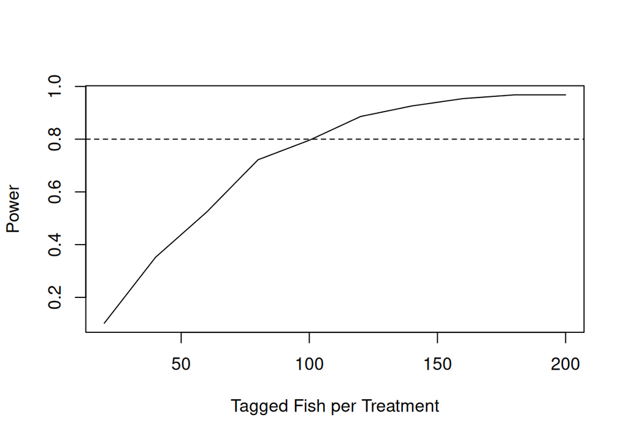

```r
n_try <- seq(20, 200, 20)
N <- length(n_try)
I <- 500
out_sig <- matrix(NA, I, N)
for (n in 1:N) {
  for (i in 1:I) {
    out_sig[i,n] <- sim_fit(n = n_try[n])["sig_pval"]
  }
}
power <- apply(out_sig, 2, mean)
plot(power ~ n_try, type = "l",
     xlab = "Tagged Fish per Treatment", ylab = "Power")
abline(h = 0.8, lty = 2)
```

```r
n_try[which(power >= 0.8)[1]]
```

```
[1] 120
```

You need roughly 100–120 fish **per treatment**, i.e. well over twice the planned budget of 100 fish in total.

**2.** `p_new` is an argument of the function, so change it in the call:

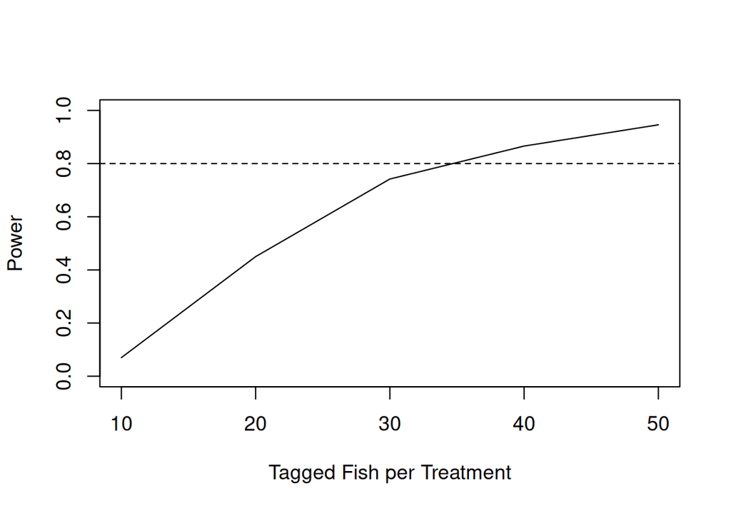

```r
n_try <- seq(10, 50, 10)
N <- length(n_try)
out_sig_40 <- matrix(NA, I, N)
for (n in 1:N) {
  for (i in 1:I) {
    out_sig_40[i,n] <- sim_fit(n = n_try[n], p_new = 0.4)["sig_pval"]
  }
}
plot(apply(out_sig_40, 2, mean) ~ n_try, type = "l", ylim = c(0, 1),
     xlab = "Tagged Fish per Treatment", ylab = "Power")
abline(h = 0.8, lty = 2)
```

A larger effect is easier to detect, so **fewer** fish are needed. About 35–40 per treatment gives a power of about 0.8, which fits within the budget of 100 fish.

**3.** Put the `cat()` line inside the outer loop. The `"\r"` returns the cursor to the start of the line, so the message overwrites itself instead of filling the console.

```r
for (n in 1:N) {
  cat("\r", "Sample Size = ", n_try[n])
  for (i in 1:I) {
    tmp <- sim_fit(n = n_try[n])
    out_sig[i,n] <- tmp["sig_pval"]
    out_prc[i,n] <- tmp["prc_est"]
  }
}
```

# 14 Exercise D: harvest policy analysis

*Builds on Section 8.*

1. Add an argument to `ricker_sim()` that optionally plots the time series of recruitment, harvest and escapement together. The default should be *not* to plot.
2. Add an **error handler** that stops the function with an informative message `if()` the names of `params` are not what the function expects (use `stop()`).
3. How does the trade-off change if the process error is larger (a larger $\sigma$)?
4. Add **implementation error**. With target exploitation rate $U$, let the realised rate in year $y$ be $U_y \sim \text{Beta}(a, b)$, with $a = 50U$ and $b = 50(1-U)$. A smaller number than 50 gives more implementation error. How does this affect the trade-off?
5. *(Bonus)* Show graphically how variable the beta random variable is when `B_sum = 50`.

**TipSolution D**

**1 & 2.** The version below includes the plot argument, the error handler, and (anticipating question 4) an implementation-error argument `B_sum`. With `B_sum = Inf` (the default) there is no implementation error.

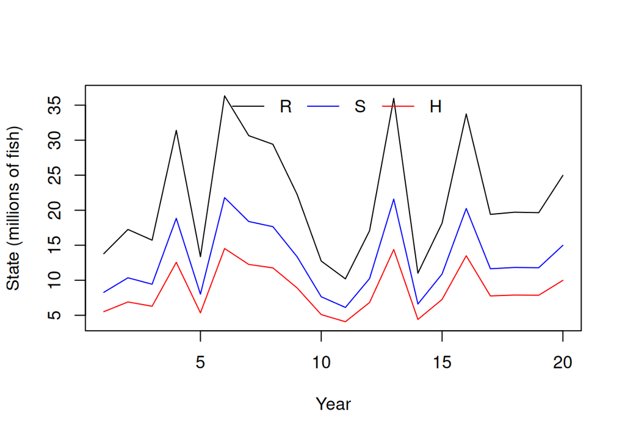

```
$mean_H
[1] 8657145

$mean_S
[1] 12985718
```

```r
ricker_sim <- function(ny, params, U, plot = F, B_sum = Inf) {
  # error handler
  if (!all(c("alpha", "beta", "sigma") %in% names(params))) {
    stop("the `params` argument must be a named vector
         with three elements: 'alpha', 'beta', and 'sigma'")
  }
  alpha <- params["alpha"]
  beta <- params["beta"]
  sigma <- params["sigma"]

  # realised exploitation rate each year
  if (is.finite(B_sum)) {
    U_real <- rbeta(ny, B_sum * U, B_sum * (1 - U))
  } else {
    U_real <- rep(U, ny)
  }

  R <- S <- H <- NULL
  R[1] <- log(alpha * (1 - 0.4))/(beta * (1 - 0.4)) * exp(rnorm(1, 0, sigma))
  S[1] <- R[1] * (1 - U_real[1])
  H[1] <- R[1] * U_real[1]
  for (y in 2:ny) {
    R[y] <- S[y-1] * alpha * exp(-beta * S[y-1] + rnorm(1, 0, sigma))
    S[y] <- R[y] * (1 - U_real[y])
    H[y] <- R[y] * U_real[y]
  }

  if (plot) {
    # I() lets you calculate a quantity inside the formula
    plot(I(R/1e6) ~ seq(1,ny), type = "l", col = "black",
         xlab = "Year", ylab = "State (millions of fish)",
         ylim = range(c(R, S, H)/1e6) + c(0,0.2))
    lines(I(S/1e6) ~ seq(1,ny), col = "blue")
    lines(I(H/1e6) ~ seq(1,ny), col = "red")
    legend("top", legend = c("R", "S", "H"), lty = 1, bty = "n",
           col = c("black", "blue", "red"), horiz = T)
  }

  list(mean_H = mean(H), mean_S = mean(S))
}

ricker_sim(ny = 20, params = c(alpha = 6, beta = 1e-7, sigma = 0.4),
           U = 0.4, plot = T)
```

The error handler at work:

```r
ricker_sim(ny = 20, params = c(a = 6, b = 1e-7, s = 0.4), U = 0.4)
```

```
Error in `ricker_sim()`:
! the `params` argument must be a named vector
         with three elements: 'alpha', 'beta', and 'sigma'
```

**3.** Write a helper that runs the whole trade-off analysis for one set of settings. To save time it collects both harvest and escapement in a single pass, and it uses 1000 replicates:

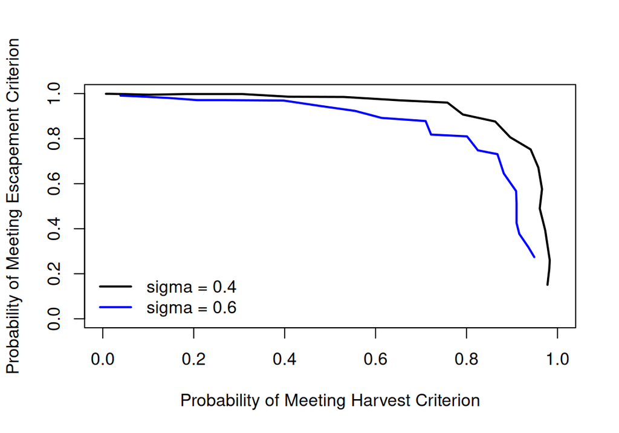

```r
tradeoff <- function(params, B_sum = Inf, U_try = seq(0.4, 0.6, 0.01), n_rep = 1000) {
  res <- sapply(U_try, function(u) {
    sims <- replicate(n_rep, unlist(ricker_sim(20, params, u, B_sum = B_sum)))
    c(p_H = mean(sims["mean_H",]/1e6 > 1.2 * 8.5),
      p_S = mean(sims["mean_S",]/1e6 > 0.75 * 13))
  })
  colnames(res) <- U_try
  res
}

base   <- tradeoff(c(alpha = 6, beta = 1e-7, sigma = 0.4))
high_s <- tradeoff(c(alpha = 6, beta = 1e-7, sigma = 0.6))

plot(base["p_S",] ~ base["p_H",], type = "l", lwd = 2,
     xlim = c(0, 1), ylim = c(0, 1),
     xlab = "Probability of Meeting Harvest Criterion",
     ylab = "Probability of Meeting Escapement Criterion")
lines(high_s["p_S",] ~ high_s["p_H",], lwd = 2, col = "blue")
legend("bottomleft", legend = c("sigma = 0.4", "sigma = 0.6"),
       col = c("black", "blue"), lwd = 2, bty = "n")
```

With more process error you have to give up more on the escapement objective to reach the same level of the harvest objective. More variability means more iterations in which escapement falls below the criterion.

**4.**

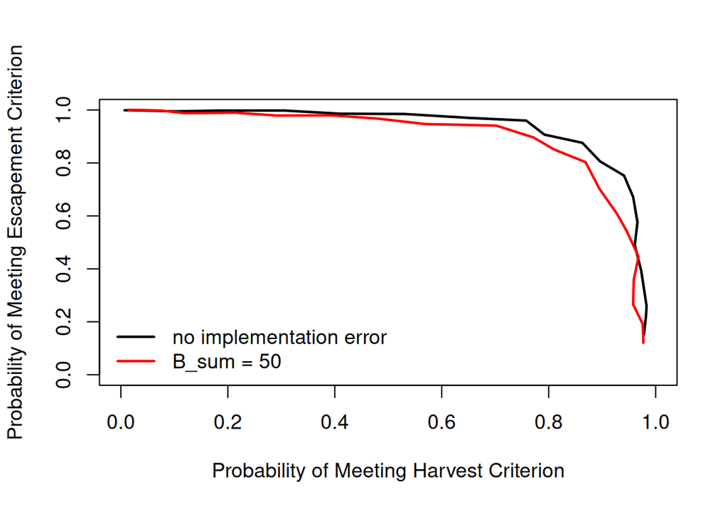

```r
impl <- tradeoff(c(alpha = 6, beta = 1e-7, sigma = 0.4), B_sum = 50)

plot(base["p_S",] ~ base["p_H",], type = "l", lwd = 2,
     xlim = c(0, 1), ylim = c(0, 1),
     xlab = "Probability of Meeting Harvest Criterion",
     ylab = "Probability of Meeting Escapement Criterion")
lines(impl["p_S",] ~ impl["p_H",], lwd = 2, col = "red")
legend("bottomleft", legend = c("no implementation error", "B_sum = 50"),
       col = c("black", "red"), lwd = 2, bty = "n")
```

Implementation error has an effect similar to larger process variance. To reach the same harvest performance you must accept a lower chance of meeting the escapement objective. Try other values of `B_sum` to see how the curve responds.

**5.** Two options: boxplots across target values, or a time series at a single target value.

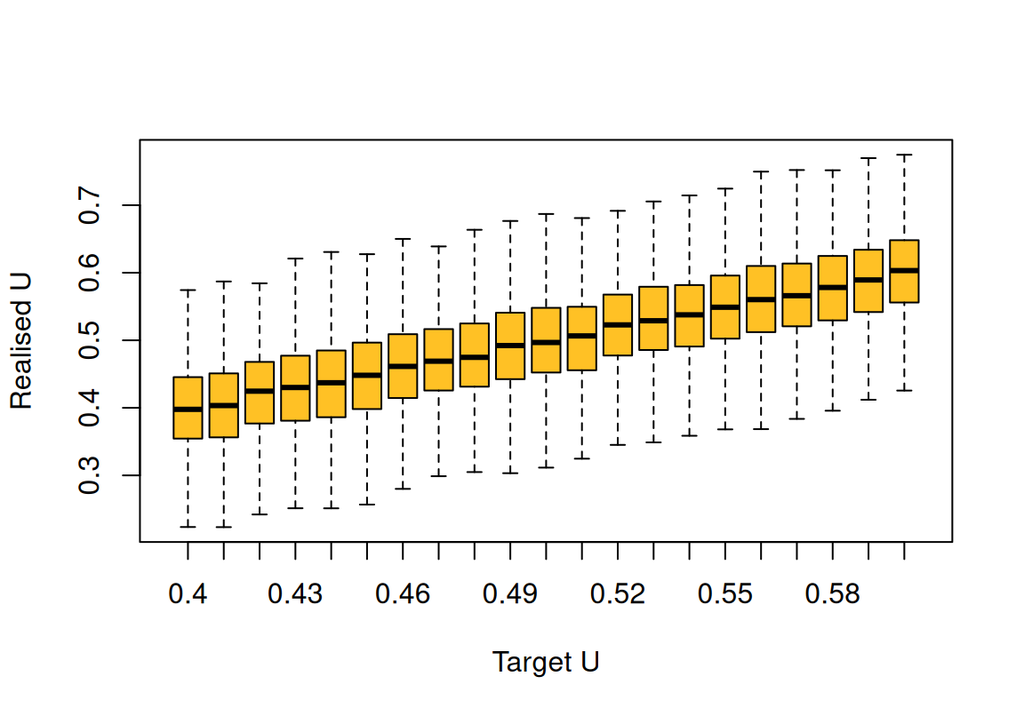

```r
B_sum <- 50
U_try <- seq(0.4, 0.6, 0.01)
out <- sapply(U_try, function(x) rbeta(n = 1000, x * B_sum, B_sum * (1 - x)))
colnames(out) <- U_try
boxplot(out, outline = F, col = "goldenrod1",
        xlab = "Target U", ylab = "Realised U")
```

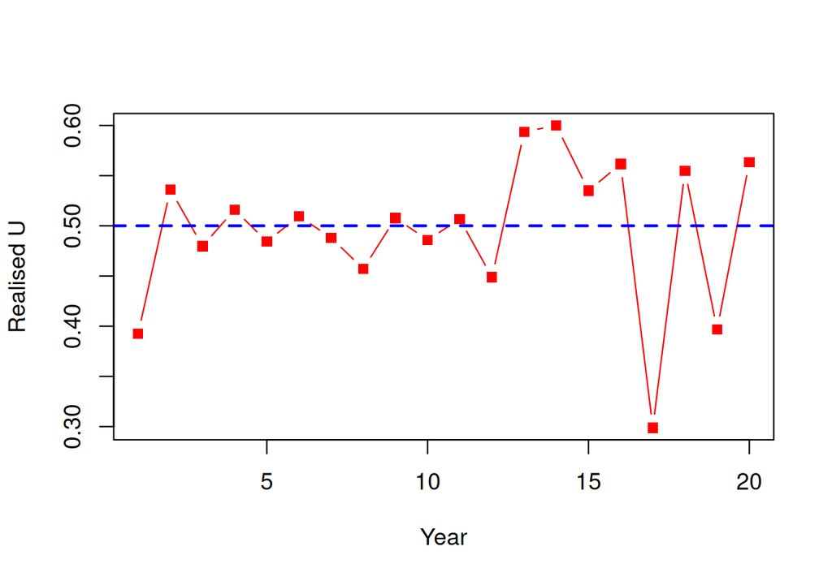

```r
U <- 0.50
plot(rbeta(20, U * B_sum, B_sum * (1 - U)), type = "b", col = "red", pch = 15,
     xlab = "Year", ylab = "Realised U")
abline(h = U, col = "blue", lty = 2, lwd = 2)
```

# 15 Exercise E: the bootstrap

*Builds on Section 9.*

1. Repeat the bootstrap for a **linear regression** of fecundity on weight in the `sockeye_redfish` data (`fecund ~ weight`). Stop once you have summarised the 95 % interval.
2. Compare the 95 % bootstrap intervals with those from `predict()` on the original data with `interval = "confidence"`.

**TipSolution E**

**1.**

```r
data(sockeye_redfish)
dat <- sockeye_redfish

randomize <- function(dat) {
  n <- nrow(dat)
  keep <- sample(x = 1:n, size = n, replace = T)
  dat[keep,]
}

fit_lm <- function(dat) {
  lm(fecund ~ weight, data = dat)
}

weights <- seq(min(dat$weight, na.rm = T), max(dat$weight, na.rm = T),
              length = 100)
pred_lm <- function(fit) {
  ests <- coef(fit)
  ests["(Intercept)"] + ests["weight"] * weights
}

out <- replicate(n = 5000, expr = {
  pred_lm(fit = fit_lm(dat = randomize(dat = dat)))
})

summ <- apply(out, 1, function(x) c(mean = mean(x), quantile(x, c(0.025, 0.975))))
```

**2.**

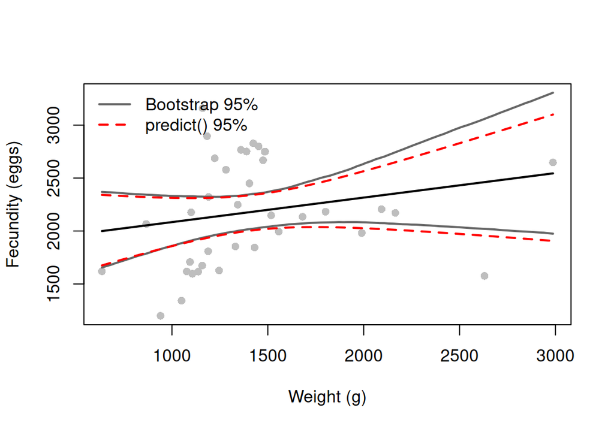

```r
pred <- predict(lm(fecund ~ weight, data = dat),
               newdata = data.frame(weight = weights),
               interval = "confidence")

plot(fecund ~ weight, data = dat, pch = 16, col = "grey",
     ylim = range(c(summ, pred, dat$fecund), na.rm = T),
     xlab = "Weight (g)", ylab = "Fecundity (eggs)")
lines(summ["mean",] ~ weights, lwd = 2)
lines(summ["2.5%",] ~ weights, col = "grey40", lwd = 2)
lines(summ["97.5%",] ~ weights, col = "grey40", lwd = 2)
lines(pred[,"lwr"] ~ weights, col = "red", lty = 2, lwd = 2)
lines(pred[,"upr"] ~ weights, col = "red", lty = 2, lwd = 2)
legend("topleft", bty = "n", lwd = 2, lty = c(1, 2),
       col = c("grey40", "red"), legend = c("Bootstrap 95%", "predict() 95%"))
```

The two sets of intervals agree closely. The bootstrap intervals are somewhat wider at the extremes of `weight`, where there are few observations.

# 16 Exercise F: permutation tests

*Builds on Section 10.*

1. Run a permutation test for the difference between treatments in each of the four zooplankton densities in `ponds`. Remember that `chao` contains a missing value.
2. Run a permutation test on another data set with a categorical and a continuous variable, e.g. `sockeye_redfish`, `growth` or `creel`.
3. Add a **one-tailed** p-value (for the hypothesis that the difference is greater than, or less than, zero). All you need are `Dnull` and `Dobs`.

**TipSolution F**

**1.** Add an `na.rm` argument to `perm()` and loop over the taxa. A loop is more compact than the four copy-pasted blocks in the original solution.

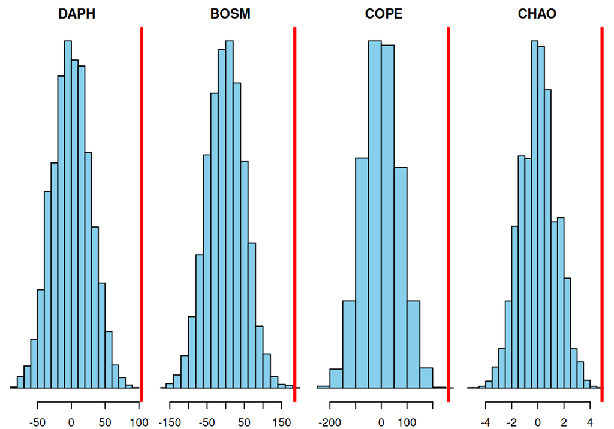

```r
data(ponds)
dat <- ponds

perm <- function(x, y, na.rm = T) {
  x <- as.character(x)
  x_shuff <- sample(x)
  x_bar_add <- mean(y[x_shuff == "Add"], na.rm = na.rm)
  x_bar_ctl <- mean(y[x_shuff == "Control"], na.rm = na.rm)
  x_bar_add - x_bar_ctl
}

taxa <- c("daph", "bosm", "cope", "chao")
par(mfrow = c(1,4), mar = c(2,0.5,2,0.5))
p_vals <- NULL
for (tx in taxa) {
  y <- dat[[tx]]
  Dobs <- mean(y[dat$treatment == "Add"], na.rm = T) -
    mean(y[dat$treatment == "Control"], na.rm = T)
  Dnull <- replicate(n = 5000, expr = perm(x = dat$treatment, y = y))
  hist(Dnull, col = "skyblue", main = toupper(tx), yaxt = "n",
       xlim = range(c(Dnull, Dobs)))
  abline(v = Dobs, col = "red", lwd = 3)
  p_vals[tx] <- mean(abs(Dnull) >= abs(Dobs))
}
```

```r
p_vals
```

```
 daph  bosm  cope  chao
0e+00 2e-04 0e+00 2e-04
```

All four zooplankton densities differ significantly between the treatments.

**2.** Compare the mean length of age 3 and age 4 fish in `growth`:

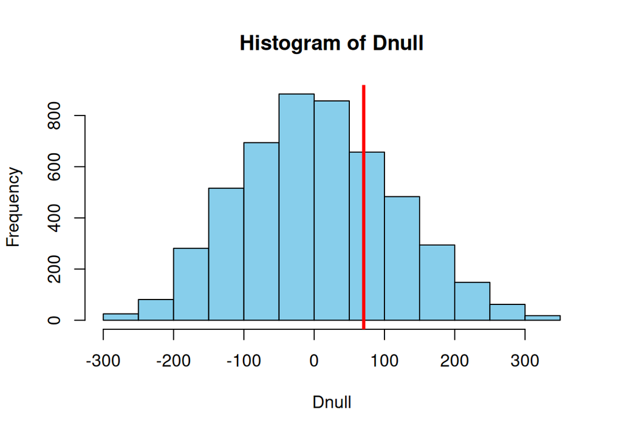

```r
data(growth)
dat <- growth[growth$age %in% c(3,4),]
Dobs <- mean(dat$length[dat$age == 4]) - mean(dat$length[dat$age == 3])

perm <- function(x, y) {
  x_shuff <- sample(x)
  mean(y[x_shuff == 4]) - mean(y[x_shuff == 3])
}
Dnull <- replicate(n = 5000, expr = perm(x = dat$age, y = dat$length))

par(mfrow = c(1,1))
hist(Dnull, col = "skyblue")
abline(v = Dobs, col = "red", lwd = 3)
```

```r
mean(abs(Dnull) >= abs(Dobs))
```

```
[1] 0.5302
```

There is no significant difference in mean length between age 3 and age 4 fish in these data.

**3.** One-tailed p-values:

```r
# H0: mean(age 4) <= mean(age 3); HA: age 4 fish are longer
mean(Dnull >= Dobs)
```

```
[1] 0.272
```

```r
# H0: mean(age 4) >= mean(age 3); HA: age 4 fish are shorter
mean(Dnull <= Dobs)
```

```
[1] 0.7288
```

# Summary

| Task | Key functions |
| --- | --- |
| Random deviates | `rnorm()`, `rbinom()`, `rlnorm()`, `rbeta()`, `rmultinom()` |
| Resampling | `sample(x, size, replace, prob)` |
| Reproducibility | `set.seed()` |
| Replication | `replicate()`, `for()`, `sapply()` |
| Summaries | `apply()` + `mean()`, `quantile()`; `table()`; `mean(logical)` |
| Distribution checks | `quantile()` vs. `q*()`, `ecdf()` vs. `p*()` |

Every Monte Carlo analysis in this module follows the same recipe:

1. write the random process as a function;
2. replicate it many times;
3. summarise the distribution of the output.

The five examples differ only in *what* is randomised:

| Example | What is randomised |
| --- | --- |
| Test `rnorm()` | draws from a known distribution |
| Power analysis | simulated data from an assumed effect |
| Harvest policy | process noise in population dynamics |
| Bootstrap | the observed data, resampled with replacement |
| Permutation test | the group labels, shuffled |

# Changes from the original material

This module reorganises Chapter 4 and its exercise solutions from B. Staton, *Introduction to R for Natural Resource Scientists* (https://bstaton1.github.io/au-r-workshop/, CC0). The main changes are:

- **Assignment operator:** all assignments use `<-` instead of the book’s `=`, following common R style guides. `=` is still used to name function arguments, e.g. `rnorm(n = 10)`.
- **Data** are loaded from the course package `qsbsdata` instead of `read.csv()` with relative paths. The `#VALUE!` error in `ponds.csv` is already converted to `NA` there, and the book’s `sockeye` is called `sockeye_redfish`.
- **R ≥ 4.0 compatibility:** `data.frame()` no longer creates factors by default, so the original `relevel(df$method, ref = "old")` fails. It has been replaced by `factor(..., levels = c("old", "new"))`.
- **Permutation p-value:** it now uses `abs(Dobs)`, so it is correct for negative observed differences. A note on the “+1” correction was added.
- **Harvest example:** the code for `S_out` (escapement), which the book only described in words, was added. `round()` guards against floating-point mismatches in `%in%`.
- **Solutions:** where the original gave only a description or a figure, runnable code was added (Exercise C1/C2, D3–D4 via a `tradeoff()` helper, and the E2 comparison plot). The four copy-pasted blocks in F1 were replaced by a loop.
- **Exercise D4:** the chapter text uses $a = 100U$, while the solutions use $a = 50U$. This module uses 50 throughout.
- Learning objectives, time estimates, callout boxes and a summary were added for self-study.

# Further reading

- Bolker, B.M. (2008). *Ecological Models and Data in R*, Ch. 5 “Stochastic simulation and power analysis”. https://ms.mcmaster.ca/~bolker/emdbook/
- Manly, B.F.J. & Navarro Alberto, J.A. (2021). *Randomization, Bootstrap and Monte Carlo Methods in Biology*, 4th ed. CRC Press.
- Shoemaker, K.T. NRES 746 – “Why simulate?” https://kevintshoemaker.github.io/NRES-746/LECTURE1.html
- Zelený, D. Monte Carlo permutation tests in community ecology. https://www.davidzeleny.net/anadat-r/doku.php/en:monte_carlo